# Exploring Walleye Population Decline in Wisconsin’s Lakes

## Results

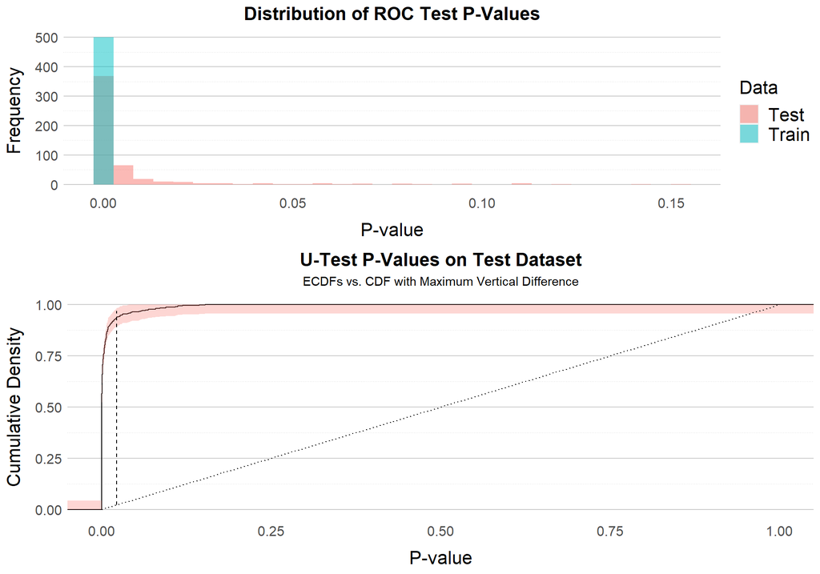

```r
# Distribution of roc.area() p-values (One-ROC test)
one_test_p <- one_test_tibble %>%
ggplot(aes(p.value, fill=train_or_test)) +
  geom_histogram(alpha=0.5, position="identity") +
  theme_general +
  labs(title="Distribution of ROC Test P-Values",
       x="P-value", y="Frequency") +
  scale_fill_manual(values=ggplotColours(n=2),
                    labels=c("Test", "Train"),
                    name="Data")

# ECDF - one-ROC test
ecdf_one_test <- one_test_tibble %>%
  mutate(e_c = ecdf(p.value)(p.value))

mx_dif_one <- ecdf_one_test %>%
  slice(which.max(abs(ecdf(p.value)(p.value)-punif(p.value))))

eps_one <- sqrt((1/(2*nrow(one_test_tibble)))*log(2/0.05))

one_test_ecdf_p <- ecdf_one_test %>%
  dplyr::filter(train_or_test=="test") %>%
ggplot(aes(x=p.value)) +
      geom_step(stat="ecdf") +
      geom_ribbon(aes(x=p.value,
                      ymin=pmax(..y..-eps_one, 0),
                      ymax=pmin(..y..+eps_one, 1),
                      fill=train_or_test),
                  stat="ecdf", alpha=0.3, lty=0,
                  show.legend = F) +
      theme_general +
      stat_function(fun=punif, lty=3,
                    col="black",
                    show.legend = F) +
      labs(title = "U-Test P-Values on Test Dataset",
           subtitle = "ECDFs vs. CDF with Maximum Vertical Difference",
           x="P-value", y="Cumulative Density") +
  geom_segment(data=mx_dif_one,
                 aes(x = p.value, xend=p.value,
                     yend=e_c,
                     y=qunif(p.value)), lty = 2) +
  scale_linetype_manual(values=c(1, 3, 2),
                        labels=c("ECDF", "Theoretical CDF",
                                 "Maximum Difference")) +
  xlim(c(0, 1))

plot_grid(one_test_p, one_test_ecdf_p, nrow=2,
          rel_heights = c(3/7, 4/7))
```

The result of the Kolmogorov-Smirnov test shows that the model outperforms naive guessing, both on the training set—an unsurprising result—and on the test set. This means, directly, that the distribution of the p-values for the Mann-Whitney $U$ tests was disproportionately small relative to the assumed null uniform distribution. This further implies that the Mann-Whitney $U$ tests found substantial evidence in support of the model’s discriminatory capabilities for novel data and, in turn, provides substantial evidence that the model can meaningfully predict whether a novel recruitment will be successful or unsuccessful. This result suggests that the model outlined in this appendix can meaningfully supplement existing WDNR walleye population models.

[^1]: The difference in negative binomial distributions, specifically $\theta$ vs. $\kappa$, is due to the different packages used to fit the models. The YOY negative binomial model was fit using the `lme4` package, which does not allow for zero-inflated models and uses $\theta=1/\kappa$ as the dispersion parameter, while the zero-inflated model was fit using the `glmmTMB` package, which uses $\kappa=1/\theta$ as a shape parameter (Bates et al. 2015; Brooks et al. 2017). Some sources refer to the `glmmTMB` shape parameter as $\alpha$, which is already in use as a random effect coefficient, so $\kappa$—a common choice for the negative binomial shape parameter—was used instead.
[^2]: Although the Durbin-Watson test is designed for normally distributed residuals, Hartig notes “[i]n simulations, I didn’t see a problem with this [scaled residuals] setting” (2020b).
[^3]: Confidence intervals for the empirical distribution functions calculated using the Dvoretzky–Kiefer–Wolfowitz inequality found in Dvoretzky et al. (Dvoretzky, Kiefer, and Wolfowitz 1956).